# Introduction to Data Cleaning with the Tidyverse

### Data transformations

#### The `mutate()` function to define new variables

Mutate functions have the formulation: `mutate(data, new_var_name = data_transformation)`. New variables are declared on the left and the right provides the operations for variable creation itself. Many operations are allowed within a mutate function:

```r
barley_HI <- mutate(nass_barley,
                    harvest_index = acres/yield,
                    Year = as.factor(year),
                    Is_high = acres > median(acres),
                    crop = "barley",
                    relative_yld = yield/mean(yield))

head(barley_HI)
```

```
##   year       state acres yield harvest_index Year Is_high   crop
## 1 1866 Connecticut  1000  22.5      44.44444 1866   FALSE barley
## 2 1866    Illinois 96000  23.4    4102.56410 1866    TRUE barley
## 3 1866     Indiana 11000  23.0     478.26087 1866   FALSE barley
## 4 1866        Iowa 66000  22.0    3000.00000 1866    TRUE barley
## 5 1866      Kansas  2000  23.0      86.95652 1866   FALSE barley
## 6 1866    Kentucky 10000  23.5     425.53191 1866   FALSE barley
##   relative_yld
## 1    0.6494957
## 2    0.6754755
## 3    0.6639290
## 4    0.6350625
## 5    0.6639290
## 6    0.6783622
```

#### Renaming variables

The `rename()` function renames columns using this notation: `rename(dataframe, newname = "oldname")`:

```r
barley_HI <- rename(barley_HI, high_acres = "Is_high")
str(barley_HI)
```

```
## 'data.frame':    4839 obs. of  9 variables:
##  $ year         : int  1866 1866 1866 1866 1866 1866 1866 1866 1866 1866 ...
##  $ state        : Factor w/ 47 levels "Alabama","Alaska",..: 7 11 12 13 14 15 16 18 19 20 ...
##  $ acres        : num  1000 96000 11000 66000 2000 10000 34000 7000 21000 20000 ...
##  $ yield        : num  22.5 23.4 23 22 23 23.5 21.5 25.5 26 26 ...
##  $ harvest_index: num  44.4 4102.6 478.3 3000 87 ...
##  $ Year         : Factor w/ 146 levels "1866","1867",..: 1 1 1 1 1 1 1 1 1 1 ...
##  $ high_acres   : logi  FALSE TRUE FALSE TRUE FALSE FALSE ...
##  $ crop         : chr  "barley" "barley" "barley" "barley" ...
##  $ relative_yld : num  0.649 0.675 0.664 0.635 0.664 ...
```

#### Splitting and Merging Columns

Combine multiple columns into one with the function `unite()`. Column data are pasted together as text, not added as numbers. The columns used to make the new variables are automatically discarded (this behavior can be stopped with the argument `remove = F`).

`unite()` functions have this formulation: `unite(data, new_var_name, vars_to_select)`.

```r
cotton_nass_new <- unite(nass_cotton, "ID", state, year)
head(cotton_nass_new)
```

```
## # A tibble: 6 x 3
##   ID                 acres yield
##   <chr>              <dbl> <dbl>
## 1 Alabama_1866      977000   120
## 2 Arkansas_1866     489000   198
## 3 Florida_1866      155000   123
## 4 Georgia_1866      895000   122
## 5 Louisiana_1866   1020000    57
## 6 Mississippi_1866 1668000    86
```

The Opposite function,`separate()`, has this structure: `separate(data, col_to_split, names_of_new_cols)`

```r
cotton_nass_new2 <- separate(cotton_nass_new,
                             col = ID,
                             into = c("STATE", "YEAR"),
                             sep = "_",
                             remove = F)
head(cotton_nass_new2)
```

```
## # A tibble: 6 x 5
##   ID               STATE       YEAR    acres yield
##   <chr>            <chr>       <chr>   <dbl> <dbl>
## 1 Alabama_1866     Alabama     1866   977000   120
## 2 Arkansas_1866    Arkansas    1866   489000   198
## 3 Florida_1866     Florida     1866   155000   123
## 4 Georgia_1866     Georgia     1866   895000   122
## 5 Louisiana_1866   Louisiana   1866  1020000    57
## 6 Mississippi_1866 Mississippi 1866  1668000    86
```

These last two functions are often quite useful - for pulling apart complicated ID columns, or for creating a unique identifier that can later be used for merging two data sets together.

### Merging data sets with ‘dplyr’

Merging different data sets by a common variable is a major advantage to using automated software. Doing this manually in spreadsheet programs is nearly impossible to do without introducing errors. There are 6 different merging or joining functions which differ in what data they keep and what are discarded.

#### Standard join functions

For merging 2 data frames. Join functions are first and foremost defined by the rows they return. The function use a common ID, which can be automatically detected or explicitly declared, to match observations in A with observations in B and returned a merged data frame. In most cases, all columns from both data frames are returned.

The general formulation for join functions: `type_join(x_data, y_data, ID_key_variable)`

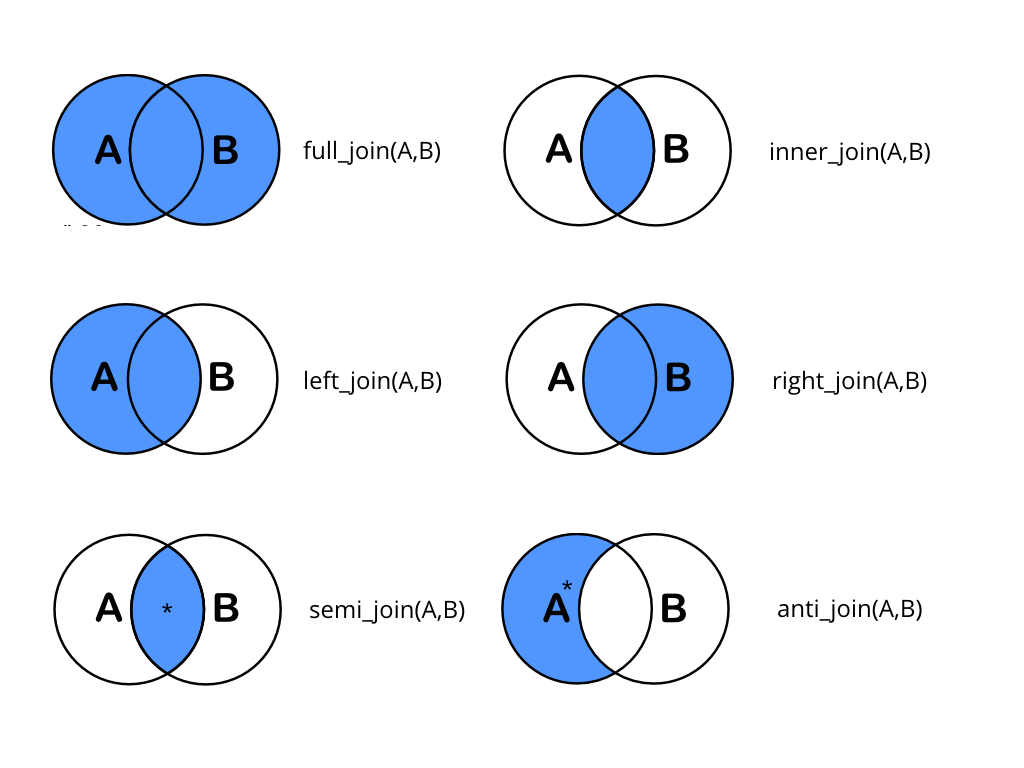

**Know Your Joins**

The column(s) used for ID are only included once in the merged data frame, that is, the duplicated key column is dropped. However, if there are other (non-ID) columns with duplicated names across the data sets, the duplicate columns from first data set listed are given a “.x” suffix and the duplicate columns from second data set listed are given a “.y” suffix.

**1. The `full_join()`:**  
- always the safest option, everything is returned - searches and matches when both the year and state of a single observation match the year and state:

```r
# first create a unique identifier variable
cotton_nass_new <- unite(nass_cotton, "ID", state, year)
barley_nass_new <- unite(nass_barley, "ID", state, year)

#equivalent models - this is only true for full_joins
cotton_barley_all <- full_join(nass_cotton, nass_barley, by = c("year", "state"))
cotton_barley_all2 <- full_join(cotton_nass_new, barley_nass_new, by = "ID")

# compare dimensions after the joins - what is kept?
dim(cotton_barley_all)
```

```
## [1] 5935    6
```

```r
dim(nass_cotton)
```

```
## [1] 2338    4
```

```r
dim(nass_barley)
```

```
## [1] 4839    4
```

```
- **Note:** for the rest of the joins, which employ a filtering step, always use a single unique identifier (called a "key") for the joins.
- When there is not a match, the rows from each data set are still returned and filled with NA for columns from the other data set.
```

**2. The `inner_join()`:**  
- this function only keeps what is common between data sets:

```r
cotton_barley_inner <- inner_join(cotton_nass_new, barley_nass_new, by = "ID")
dim(cotton_barley_inner)
```

```
## [1] 1242    5
```

```r
head(cotton_barley_inner)
```

```
## # A tibble: 6 x 5
##   ID             acres.x yield.x acres.y yield.y
##   <chr>            <dbl>   <dbl>   <dbl>   <dbl>
## 1 Tennessee_1866  649000     121    4000      23
## 2 Texas_1866      490000     325    3000      16
## 3 Tennessee_1867  611000     137    4000      19
## 4 Texas_1867      491000     195    2000      20
## 5 Tennessee_1868  520000     170    4000      18
## 6 Texas_1868      581000     197    2000      22
```

```
- several column names duplicates resulted in the addition of ".x" to duplicate columns from the cotton data set and ".y" to duplicate columns from the barley data set.
```

```r
colnames(cotton_barley_inner)[2:5] <- c("cotton_acres", "cotton_yield", "barley_acres", "barley_yield")
```

**3. The `left_join()`:**  
- matches all rows for observations found in the tibble listed on the left:

```r
cotton_barley_left <- left_join(cotton_nass_new, barley_nass_new, by = "ID")
dim(cotton_barley_left)
```

```
## [1] 2338    5
```

```r
cotton_barley_right <- right_join(cotton_nass_new, barley_nass_new, by = "ID")
dim(cotton_barley_right)
```

```
## [1] 4839    5
```

**5. The `semi_join()`:**  
- This function is like `inner_join()` (only rows with keys in both data sets are kept) except it does not keep any data from the data set listed second:

```r
cotton_barley_semi <- semi_join(cotton_nass_new, barley_nass_new, by = "ID")
dim(cotton_barley_semi)
```

```
## [1] 1242    3
```

```r
str(cotton_barley_semi)
```

```
## Classes 'tbl_df', 'tbl' and 'data.frame':    1242 obs. of  3 variables:
##  $ ID   : chr  "Tennessee_1866" "Texas_1866" "Tennessee_1867" "Texas_1867" ...
##  $ acres: num  649000 490000 611000 491000 520000 581000 502000 720000 536000 922000 ...
##  $ yield: num  121 325 137 195 170 197 145 195 203 255 ...
```

```r
str(cotton_barley_inner)
```

```
## Classes 'tbl_df', 'tbl' and 'data.frame':    1242 obs. of  5 variables:
##  $ ID          : chr  "Tennessee_1866" "Texas_1866" "Tennessee_1867" "Texas_1867" ...
##  $ cotton_acres: num  649000 490000 611000 491000 520000 581000 502000 720000 536000 922000 ...
##  $ cotton_yield: num  121 325 137 195 170 197 145 195 203 255 ...
##  $ barley_acres: num  4000 3000 4000 2000 4000 2000 4000 2000 4000 2000 ...
##  $ barley_yield: num  23 16 19 20 18 22 19 22 18.5 20.5 ...
```

**6. The `anti_join()`:**  
- observations from A that *do not* match B are kept:

```r
cotton_barley_anti <- anti_join(cotton_nass_new, barley_nass_new, by = "ID")
dim(cotton_barley_anti)
```

```
## [1] 1096    3
```